# Human Development and Procrastination

Jeffrey Weltman and Jordan Kassof

11/26/2017

# Introduction

JWJK Analytics conducted the below analysis to explore and hopefully understand the relationship between procrastination and human development across the globe. This information was requested by the United Nations Development Programme to help provide insight into the factors that play into human development and life satisfaction across nations. Ideally, any insights gleaned from this analysis can help the UN implement programs for social benefit across under-served areas.

# Data Sources

This analysis was conducted using two data sources. See below for details about each.

### Procrastination Survey Data

‘Procrastination.csv’ are the raw results of a research study, tabulated by Qualtrics. The study asked participants a series of demographic questions, as well as asked questions related to procrastination. Participants were also measured on several procrastination scales. The data from Qualtrics required extensive cleansing and organizing. ‘TidyProcrastination.csv’ is a cleaned up, machine-readable version of the raw data.

### Human Development Index Data

The Human Development Index (HDI) is a statistic created and distributed by the United Nations. It is a composite statistic derived using indicators for education, life expectancy, and income per capita. This score can be viewed as the potential for human development and prosperity in a given country. We access this data with an R script that scrapes the HDI Wikipedia page. See below image from Wikipedia for a high level understanding of how the HDI is calculated.

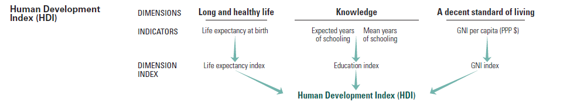

[CC BY 3.0](https://creativecommons.org/licenses/by/3.0/), [Link](https://en.wikipedia.org/w/index.php?curid=55637565)

# Data Importing & Merging

The below code chunk sources the data cleaning script for our procrastination data. See the script for details of how the file was cleaned.

```r
library(knitr)
library(kableExtra)
source("data/q2-clean-procras-raw.R")
kable(procrastination_dims,"html",row.names=FALSE) %>%
  kable_styling(bootstrap_options = c("striped","condensed"),
                full_width = FALSE)
```

| Number of Rows | Number of Columns |
| --- | --- |
| 4264 | 61 |

The below code chunk sources the Wikipedia scraping script for HDI data. See the script for details of how the data is scraped.

```r
source("data/q3-hdi-wiki-scrape.R")
```

The below code chunk merges the two data sets and saves a copy to the /data directory. See script for details of how data sets are merged.

```r
source("data/q3-merging-hdi-and-procrastination.R")
```

# Preliminary Analysis

Below we source our preliminary analysis script. See script for details of how data was summarized for the following tables and histograms.

```r
source("analysis/q4-analysis.R")
```

### Summary Statistics

To begin understanding our data, we will run some standard summary statistics for a number of key variables.

```r
# Print display friendly table of summary statistics for key variables
kable(summary_list,
      digits = 2,
      format = "html") %>%
  kable_styling(bootstrap_options = c("striped","condensed"),
                full_width = FALSE)
```

[output not shown]

### Select Histograms

Below are full sized histograms for a couple of select variables.

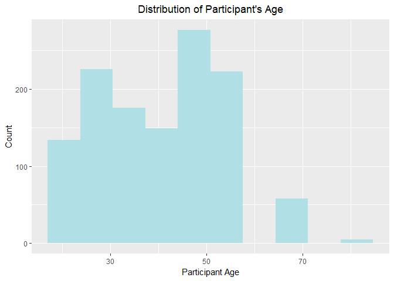

```r
library(ggplot2)
ggplot(data = na.omit(all_data), aes(x = Age)) +
  geom_histogram(bins = 10, fill = "powderblue") +
  xlab("Participant Age") +
  ylab("Count") +
  ggtitle("Distribution of Participant's Age") +
  theme(
    plot.title = element_text(hjust = .5)
  )
```

The above distribution indicates our participant’s age skews a bit to the right. The majority of our participants are in the 20-50 range although we have participants in age as high as 80.

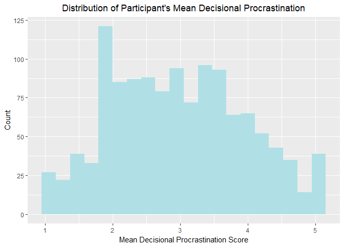

```r
ggplot(data = na.omit(all_data), aes(x = DPMean)) +
  geom_histogram(bins = 20, fill = "powderblue") +
  xlab("Mean Decisional Procrastination Score") +
  ylab("Count") +
  ggtitle("Distribution of Participant's Mean Decisional Procrastination") +
  theme(
    plot.title = element_text(hjust = .5)
  )
```

The above distribution of mean decisional procrastination is roughly symmetric around 3. The data aren’t very normal, as the decrease in count as you get further from the center is too slow to be normal.

### Key Variables Frequency Tables

To continue getting acquainted with our data, lets look at frequency tables for a number of variables.

##### Gender

```r
kable(gender_freqs, format = "html", col.names = c("Gender", "Participants")) %>%
    kable_styling(bootstrap_options = c("striped","condensed"),
                            full_width = FALSE)
```

| Gender | Participants |
| --- | --- |
| Female | 2309 |
| Male | 1721 |
| NA | 6 |

Looks like our participants tilt female, with around 57% of respondents identifying as such.

##### Work Status

```r
kable(workstatus_freqs, format = "html", col.names = c("Work Status", "Participants")) %>%
    kable_styling(bootstrap_options = c("striped","condensed"),
                            full_width = FALSE)
```

| Work Status | Participants |
| --- | --- |
| full-time | 2260 |
| student | 837 |
| part-time | 465 |
| unemployed | 258 |
| retired | 174 |
| NA | 42 |

The majority of our participants are full-time employed.

##### Occupation

```r
kable(head(occu_freqs, 10), format = "html", col.names = c("Occupation", "Participants")) %>%
    kable_styling(bootstrap_options = c("striped","condensed"),
                            full_width = FALSE) %>%
  add_footnote(label = "See 'data/occupation_counts.csv' for full table", notation = 'symbol')
```

| Occupation | Participants |
| --- | --- |
| NA | 2662 |
| Education | 155 |
| Software & IT | 66 |
| Attorney | 62 |
| Writer | 45 |
| Healthcare | 36 |
| engineer | 32 |
| manager | 32 |
| Science | 29 |
| retired | 28 |

* See ‘data/occupation_counts.csv’ for full table

It seems most participants did not provide an occupation, limiting the research utility of this variable.

##### Participants by Country

```r
kable(head(pcpts_per_country, 10), format = "html") %>%
    kable_styling(bootstrap_options = c("striped","condensed"),
                            full_width = FALSE) %>%
  add_footnote(label = "See 'data/participants_by_country.csv' for full table", notation = 'symbol')
```

| Country of Residence | Participants |
| --- | --- |
| United States | 2785 |
| Canada | 243 |
| United Kingdom | 177 |
| NA | 160 |
| Australia | 99 |
| India | 78 |
| Italy | 62 |
| Germany | 36 |
| Brazil | 20 |
| Ireland | 19 |

* See ‘data/participants_by_country.csv’ for full table

Our results are heavily skewed towards United States based participants, something to keep in mind for any insights taken away. For the purposes of the UN, it is likely we need to conduct the procrastination survey more with international participants.

##### Internal vs External Perception

```r
kable(matching_perception, format = "html") %>%
    kable_styling(bootstrap_options = c("striped","condensed"),
                            full_width = FALSE)
```

| Self Labeled | Others would Label | Observations | Total Obs |
| --- | --- | --- | --- |
| No | No | 482 | 4036 |
| Yes | Yes | 2358 | 4036 |

# Deep Dive

### Top 15 National Procrastination Scores

##### Based on Adult Inventory of Procrastination

The below code chunk generates a bar chart of the top 15 countries by average score on Adult Inventory of Procrastination.

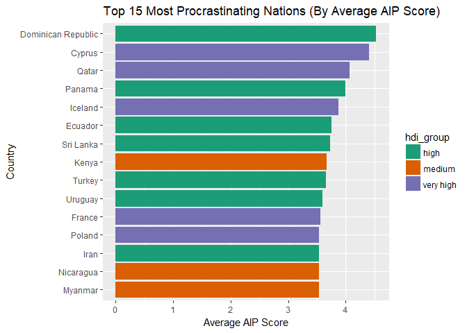

```r
source("analysis/q5_and_q6-analysis.R")

ggplot(top15_aip_hdi,aes(x=CntryOfRes, y=CntryMeanAIP,fill=hdi_group))+
  geom_bar(aes(reorder(CntryOfRes,CntryMeanAIP)), stat="identity")+
  ggtitle("Top 15 Most Procrastinating Nations (By Average AIP Score)")+
  xlab("Country")+ylab("Average AIP Score")+
  scale_fill_brewer(palette="Dark2")+
  coord_flip()
```

12 of the top 15 nations with the highest Adult Inventory of Procrastination scale scores have either a *very high* or *high* HDI rating. Kenya, Nicaragua, and Myanmar, *medium* HDI nations, complete the top 15.

##### Based on General Procrastination scale

The below code chunk generates a bar chart of the top 15 countries by average score on General Procrastination scale.

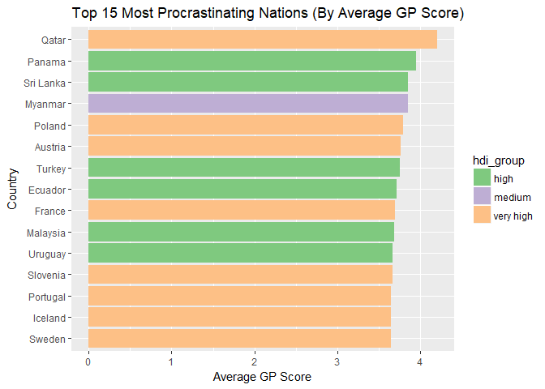

```r
ggplot(top15_gp_hdi,aes(x=CntryOfRes, y=CntryMeanGP,fill=hdi_group))+
  geom_bar(aes(reorder(CntryOfRes,CntryMeanGP)), stat="identity")+
  ggtitle("Top 15 Most Procrastinating Nations (By Average GP Score)")+
  xlab("Country")+ylab("Average GP Score")+
  scale_fill_brewer(palette="Accent")+
  coord_flip()
```

14 of the top 15 nations with the highest General Procrastination scale scores have either a *very high* or *high* HDI rating. Myanmar, a *medium* HDI nation, is the only exception.

##### Examining Highest Scoring Nations Across Adult Inventory of Procrastination and General Procrastination scales

The table below displays the nations, their mean scores, their HDI score, and their *hdi_group*.

```r
knitr::kable(top_procrastinators,"html",row.names=FALSE) %>%
  kableExtra::kable_styling(bootstrap_options = c("striped","condensed"),
                            full_width=FALSE)
```

| CntryOfRes | CntryMeanAIP | CntryMeanGP | HDI | hdi_group |
| --- | --- | --- | --- | --- |
| Ecuador | 3.753333 | 3.716667 | 0.739 | high |
| France | 3.563846 | 3.692308 | 0.897 | very high |
| Iceland | 3.870000 | 3.650000 | 0.921 | very high |
| Myanmar | 3.530000 | 3.850000 | 0.556 | medium |
| Panama | 4.000000 | 3.950000 | 0.788 | high |
| Poland | 3.532000 | 3.790000 | 0.855 | very high |
| Qatar | 4.070000 | 4.200000 | 0.856 | very high |
| Sri Lanka | 3.730000 | 3.850000 | 0.766 | high |
| Turkey | 3.654444 | 3.755556 | 0.767 | high |
| Uruguay | 3.600000 | 3.666667 | 0.795 | high |

10 nations rank in the top 15 AIP and GP scores. Of these 10 nations, 4 have a *very high* HDI rating, 5 have a *high* HDI rating, and only one - Myanmar - has a *medium* HDI rating.

### Linear Relationships Across Variables

The below code chunk generates a scatter plot of Annual Income vs Age to infer whether a linear relationship exists.

##### Income versus Age

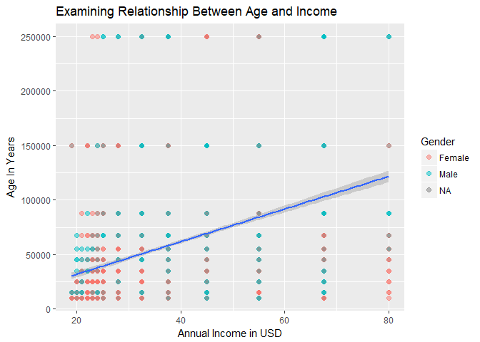

```r
ggplot(data = all_data, aes(x = Age, y = AnnualIncome)) +
  geom_point(size = 2, na.rm = TRUE,  alpha = 0.5, aes(color = Gender)) +
  geom_smooth(method = "lm", na.rm = TRUE) +
  xlab("Annual Income in USD")+ylab("Age In Years")+
  ggtitle("Examining Relationship Between Age and Income")
```

```r
knitr::kable(summary(inc_vs_age.mod)$coefficients, digits = 2) %>%
    kable_styling(bootstrap_options = c("striped","condensed"),
                            full_width = FALSE) %>%
  add_footnote("Linear Model of Annual Income vs Age")
```

|  | Estimate | Std. Error | t value | Pr(>\|t\|) |
| --- | --- | --- | --- | --- |
| (Intercept) | 1950.98 | 2592.53 | 0.75 | 0.45 |
| Age | 1496.77 | 63.23 | 23.67 | 0.00 |

**Note:** <sup>a</sup> Linear Model of Annual Income vs Age

The above plot and linear model results agree, there is a significant positive relationship between annual income and age. This isn’t too surprising, older individuals tend to be more experienced and command higher incomes. That being said, the R<sub>2</sub> of our linear model is quite low, indicating age alone doesn’t provide a significant amount of information on someone’s income. Given drastically different standards and customs from country to country, it is not surprising that individuals from different countries make very different amounts of money on average.

##### Life Satisfaction versus Human Development Index

The below code chunk generates a plot of Mean Life Satisfaction scores vs HDI for the country of residence of the participant.

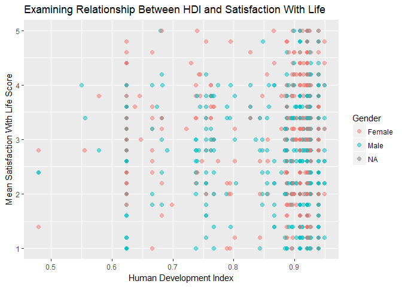

```r
ggplot(data = all_data, aes(x = HDI, y = SWLSMean, color = Gender)) +
  geom_point(size = 2, na.rm = TRUE,  alpha = 0.5) +
  xlab("Human Development Index") +
  ylab("Mean Satisfaction With Life Score") +
  ggtitle("Examining Relationship Between HDI and Satisfaction With Life")
```

The below code chunk generates a bar chart of Mean Life Satisfaction scores vs HDI category for the country of residence of the participant.

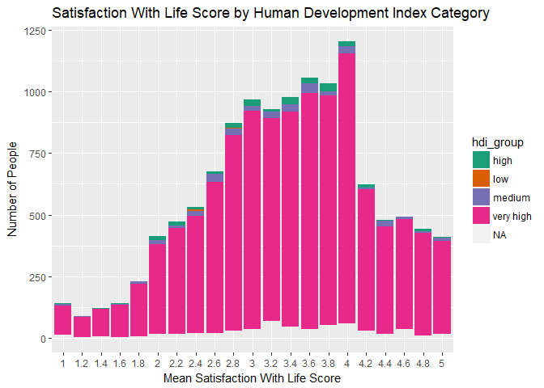

```r
ggplot(all_data,aes(x=hdi_group,y=SWLSMean,fill=hdi_group))+
  geom_bar(aes(reorder(SWLSMean,hdi_group)), stat="identity")+
  ggtitle("Satisfaction With Life Score by Human Development Index Category")+
  xlab("Mean Satisfaction With Life Score")+ylab("Number of People")+
  scale_fill_brewer(palette="Dark2")
```

# Conclusions and Next Steps

The intention of this analysis was to explore and understand the relationship between procrastination and human development across the globe. The initial findings of this analysis yielded evidence which suggests that nations with *very high* and *high* human development index ratings tend to have higher mean scores across the procrastination instruments utilized in the surveying of this population. A positive correlation between Age and Annual Income was also confirmed. Since our survey data is voluntary self-reported information, the findings of this study can only be concluded as associative within the population of the survey participants.

The sampling of the nations themselves is a potentially confounding variable. The table below illustrates the distribution of countries and their HDI ratings.

```r
knitr::kable(cat_count,"html",row.names=FALSE) %>%
  kableExtra::kable_styling(bootstrap_options = c("striped","condensed"),
                            full_width=F,
                            position="left")
```

| hdi_group | percentage |
| --- | --- |
| very high | 90.609514 |
| NA | 4.286422 |
| medium | 2.824579 |
| high | 2.180377 |
| low | 0.099108 |

Approximately 93% of the nations represented in the survey have *very high* or *high* HDI ratings. This is indicative of the need for additional research from nations with *medium* and *low* HDI ratings as an important next step. As was indicated above, the population consists largely of United States residents and full-time employed persons. Further surveying of residents from other nations, and of varying employment statuses, would be necessary in order to provide the truly global analysis sought after by the United Nations.